# Week 1. Society, yesterday and today

2026

Each week, I’ll upload a document like this to the Modules section that gives a little context for the reading, a list of other readings in the sidenotes, and other pointers for mastering the course content.

These other readings may be texts that the author has written, secondary literature (i.e., 'Recommended readings'), or any other media that might be of use in grasping what the theorist has to say.

It is obviously not an obligation to read these; however, given the nature of the readings this semester—which come to you in pieces—I recommend you use them as a way to ‘place’ the author and their work. It will likely save you some time by limiting the initial confusion that comes with facing an old text for the first time. *And I will try my best to keep them brief!*

We begin the semester with the historical emergence of something called ‘society’ (the subject matter of ‘sociology’).

Though we take it for granted, many of our thinkers this semester were fascinated by it and wondered what it was. We’re going to follow their puzzlement.

There is some useful historical background to the emergence of the notion of society, which I’ll cover in the lecture, but for which I’ll give the basic outline and some references now.

See Raymond Williams' entry for Society in his [*Keywords*](https://ebookcentral.proquest.com/lib/unimelb/reader.action?docID=679632&ppg=279&c=RVBVQg)

Some good accounts of the intellectual history of the idea that society is a kind of 'body' apart from those who rule can be found in [Kai Erikson](https://doi.org/10.12987/yale/9780300106671.003.0007), [Eric Wolf](https://www.jstor.org/stable/645518), and [Johan Heilbron](https://cat.lib.unimelb.edu.au:443/record=b1882317~S30) Essentially, society emerges at a time in which political economists and others (famously, people like John Locke and, after him, Adam Smith) observe that though the sovereign (king/queen/prince etc.) may make rules and laws, these are not necessarily followed by the populace. It was thought instead that this populace had – we might now say – a mind of its own. Some people (like our author this week, Harriet Martineau) went as far as to claim that government direction *inhibits* the proper functioning of society (many economists still argue this today). In any case, the sovereign could no longer legitimately rule her ‘subjects’ by simple decree, but had to understand (and perhaps gain the consent of) the social body she ruled over. This required experts, like political economists, statisticians, demographers, and eventually sociologists and students of public opinion who were skilled in deciphering the tendencies of this social body. Following the natural sciences, such experts often described these tendencies as ‘laws’. It was thought that just as nature had its laws that couldn’t be altered by mere arbitrary decision, so too did ‘society’ have laws that didn’t respond easily to the ruler’s efforts. Our semester begins at this point, with people who were fascinated by this new object and intent on understanding the changes it undergoes as a result of different causes.

# Where do these texts come from?

I want to avoid giving you long texts to read, but I also want to ensure that you’re not lost when you’re reading. So, each week, on top of the broad historical context, like that above, I’ll give a bit more about the immediate context of the text: its place within a book (if it’s taken from one), within a period in a writer’s life, etc.

## “Introduction” to *Society in America* by Harriet Martineau (1837)

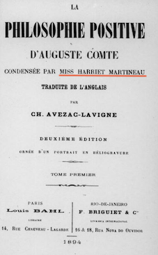

Martineau (1802-1876) was a British writer credited with being a kind of sociologist before the discipline got its name. (In fact, the person who gave sociology its name, August Comte, had his work translated from French into English by Martineau herself—a translation that was so useful it was translated *back* into French.) She wrote a couple of big books about her travels to the USA in the 1830s. We have the introduction from one of these, where she outlines the problem of how to know another society and her solutions to this problem. She also tells us all the places she visited and people she met. While reading, think about whether, if you were in her position, these are the kinds of places and people you would visit to know a ‘society’.

On the boat on the way to New York, she wrote what we would now call a methodological treatise. As its title suggests she aims to instruct readers on [*How to observe morals and manners*](https://www.gutenberg.org/ebooks/33944)

[figure not shown]

For some relatively recent accounts of Martineau, see [Sinha's chapter](https://link.springer.com/chapter/10.1057/978-1-137-41134-1_4), [Hoecker-Drysdale's](https://doi.org/10.1002/9781444396621.ch3), or Vetter's article on ['Harriet Martineau on the Theory and Practice of Democracy in America'](https://doi.org/10.1177/0090591708315147). She is also discussed among other early women sociologists by [Lengermann and Niebrugge](https://bookshelf.vitalsource.com/reader/books/9781544354842/epubcfi/6/46%5B%3Bvnd.vst.idref%3Ds9781544354866.i3376%5D!/4)

What we’re particularly interested in about her work is the problem she identifies: how to study a society. Because she thinks a society is defined by its moral principles and behaviours (‘manners’), a second question appears: what (or whose) *point of view* should we adopt when studying a society? Should we assume that our own point of view is the standard against which other societies are measured? Or should we relinquish any standards and lapse into nihilism? Martineau, though a religious woman with a steadfast moral vision, rejects both of these options. We should not ignore standards and morals – all societies have them – but we also shouldn’t take *our* morals as the benchmark. If we do that, we’ll forever find other societies inferior.

This is what she means when she writes 'I decline the office of censor altogether. I dare not undertake it' (p.ix)

Therefore, she suggests identifying a society’s reigning moral principles and then finding out how *actual* life is carried out (p.viii). When she returned to the topic of her American travel for another two volume account, she described her study as [‘an inquiry into the theory and practice of their society’](https://www.gutenberg.org/cache/epub/40280/pg40280-images.html).

## “Empire and the creation of a social science” by Raewyn Connell (2007)

Raewyn Connell is the most prominent living Australian sociologist, who has over her long career published major works on class, education, masculinity, and – our reading this week – the composition of the sociological canon.

The book that our chapter comes from is an expansion on article she published in the *American Journal of Sociology* in 1997. Her argument is a provocative one: what we consider to be our ‘classical’ sociologists only became classical long after they perished; we tell ourselves a nice story in which they were trying to understand dramatic changes affecting Europe in the 19th century, but at the time they were actually writing about societies *outside* Europe and depicting Europeans as advanced and civilised *in comparison to* premodern or ‘primitive’ non-European colonial subjects. Therefore, classical sociologists were interested less in what was going on in their own societies and more in favourably comparing their societies to others who were deemed ‘primitive’.

Connell, R. 1997. ['Why Is Classical Theory Classical?'](https://www.jstor.org/stable/10.1086/231125?seq=1)

The argument was discussed and criticised at the time. See Collins, R. 1997. ['A Sociological Guilt Trip: Comment on Connell'](https://www.jstor.org/stable/10.1086/231126)

For Connell, this is important because knowledge of society is high stakes stuff. Those of us trying to research and understand the social world risk antagonising people who benefit from these tendencies being the way they are. As she puts it bluntly, ‘The dominant powers reshaping our world seek to close down, rather than open up, the self-knowledge of society’ (p.vii).

But the theoretical tools we have at hand to do this research – tools manufactured by our classical sociological ‘Founding Fathers’ in Europe and the USA – risk concealing true knowledge of society from us. At least this is her starting point for our reading.

> social science is, at best, ambiguously democratic. Its dominant genres picture the world as it is seen by men, by capitalists, by the educated and affluent. Most important, they picture the world as seen from the rich capital-exporting countries of Europe and North America—the global metropole. To ground knowledge of society in other experiences remains a fragile project. (p.vii)

Ultimately, she makes a critical move that we’ll see a lot this semester: people (like theorists) claiming that they are speaking about universal things (society) are actually merely *universalising* their own experience of the world.

If we want theory that *actually* grasps society (rather than a false image of it), then Connell thinks we have to confront the biases implicit in our classical canon – and think about what kind of knowledge is produced by those outside of it.